# Homework

2023-10-09

## QUESTION 01: Data Visualisation for Science Communication

### a) Figure:

```
##
##  C:\Users\Envy\AppData\Local\Temp\RtmpsxRXci\downloaded_packages
```

```
##
##  C:\Users\Envy\AppData\Local\Temp\RtmpsxRXci\downloaded_packages
```

```
##
##  C:\Users\Envy\AppData\Local\Temp\RtmpsxRXci\downloaded_packages
```

```
##
##  C:\Users\Envy\AppData\Local\Temp\RtmpsxRXci\downloaded_packages
```

```
## # A tibble: 6 × 8
##   species island    bill_length_mm bill_depth_mm flipper_length_mm body_mass_g
##   <fct>   <fct>              <dbl>         <dbl>             <int>       <int>
## 1 Adelie  Torgersen           39.1          18.7               181        3750
## 2 Adelie  Torgersen           39.5          17.4               186        3800
## 3 Adelie  Torgersen           40.3          18                 195        3250
## 4 Adelie  Torgersen           NA            NA                  NA          NA
## 5 Adelie  Torgersen           36.7          19.3               193        3450
## 6 Adelie  Torgersen           39.3          20.6               190        3650
## # ℹ 2 more variables: sex <fct>, year <int>
```

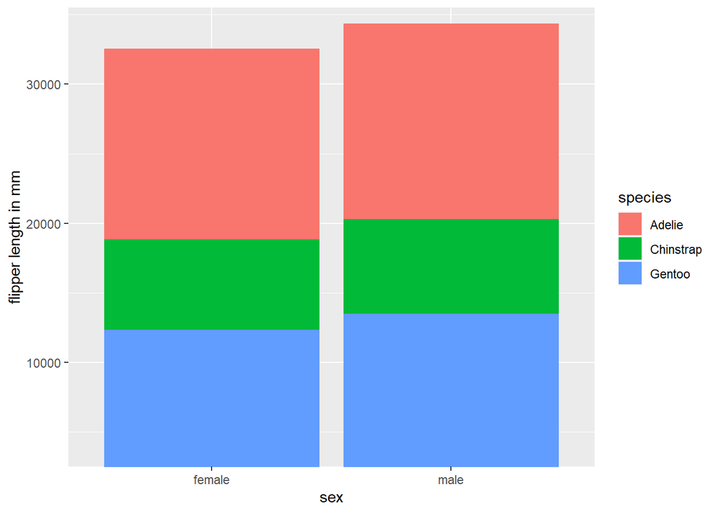

### b) Write about how your design choices mislead the reader about the underlying data (200-300 words).

This bar chart is misleading because the scale will make it quite hard to compare the bars properly. The y axis does not start at zero, but may look as if it does. It makes the differences between the sexes seem like they are greater than they are.

References: Baker, M. (2016). 1,500 scientists lift the lid on reproducibility. Nature, 533(7604), 452–454. https://doi.org/10.1038/533452aData Carpentry contributors. (2019). Data visualization with ggplot2. Datacarpentry.org. https://datacarpentry.org/R-ecology-lesson/04-visualization-ggplot2.htmlRoe-Raymond, C. S. (2020). How to Make Effective Plots (using R). https://researchcomputing.princeton.edu/sites/g/files/toruqf311/files/effplots_r_small_20200922.pdf

## QUESTION 2: Data Pipeline

### Introduction

```r
#installing and loading packages

install.packages("tinytex", repos = "http://cran.us.r-project.org")
```

```r
library(ggplot2)
library(palmerpenguins)
library(janitor)
library(dplyr)
library(tinytex)


#checking columns and full dataset
head (penguins_raw)
```

```
## # A tibble: 6 × 17
##   studyName `Sample Number` Species          Region Island Stage `Individual ID`
##   <chr>               <dbl> <chr>            <chr>  <chr>  <chr> <chr>
## 1 PAL0708                 1 Adelie Penguin … Anvers Torge… Adul… N1A1
## 2 PAL0708                 2 Adelie Penguin … Anvers Torge… Adul… N1A2
## 3 PAL0708                 3 Adelie Penguin … Anvers Torge… Adul… N2A1
## 4 PAL0708                 4 Adelie Penguin … Anvers Torge… Adul… N2A2
## 5 PAL0708                 5 Adelie Penguin … Anvers Torge… Adul… N3A1
## 6 PAL0708                 6 Adelie Penguin … Anvers Torge… Adul… N3A2
## # ℹ 10 more variables: `Clutch Completion` <chr>, `Date Egg` <date>,
## #   `Culmen Length (mm)` <dbl>, `Culmen Depth (mm)` <dbl>,
## #   `Flipper Length (mm)` <dbl>, `Body Mass (g)` <dbl>, Sex <chr>,
## #   `Delta 15 N (o/oo)` <dbl>, `Delta 13 C (o/oo)` <dbl>, Comments <chr>
```

```r
names(penguins_raw)
```

```
##  [1] "studyName"           "Sample Number"       "Species"
##  [4] "Region"              "Island"              "Stage"
##  [7] "Individual ID"       "Clutch Completion"   "Date Egg"
## [10] "Culmen Length (mm)"  "Culmen Depth (mm)"   "Flipper Length (mm)"
## [13] "Body Mass (g)"       "Sex"                 "Delta 15 N (o/oo)"
## [16] "Delta 13 C (o/oo)"   "Comments"
```

```r
#penguins_raw

#picking data I want to use
penguins_raw$`Body Mass (g)`
```

```
##   [1] 3750 3800 3250   NA 3450 3650 3625 4675 3475 4250 3300 3700 3200 3800 4400
##  [16] 3700 3450 4500 3325 4200 3400 3600 3800 3950 3800 3800 3550 3200 3150 3950
##  [31] 3250 3900 3300 3900 3325 4150 3950 3550 3300 4650 3150 3900 3100 4400 3000
##  [46] 4600 3425 2975 3450 4150 3500 4300 3450 4050 2900 3700 3550 3800 2850 3750
##  [61] 3150 4400 3600 4050 2850 3950 3350 4100 3050 4450 3600 3900 3550 4150 3700
##  [76] 4250 3700 3900 3550 4000 3200 4700 3800 4200 3350 3550 3800 3500 3950 3600
##  [91] 3550 4300 3400 4450 3300 4300 3700 4350 2900 4100 3725 4725 3075 4250 2925
## [106] 3550 3750 3900 3175 4775 3825 4600 3200 4275 3900 4075 2900 3775 3350 3325
## [121] 3150 3500 3450 3875 3050 4000 3275 4300 3050 4000 3325 3500 3500 4475 3425
## [136] 3900 3175 3975 3400 4250 3400 3475 3050 3725 3000 3650 4250 3475 3450 3750
## [151] 3700 4000 4500 5700 4450 5700 5400 4550 4800 5200 4400 5150 4650 5550 4650
## [166] 5850 4200 5850 4150 6300 4800 5350 5700 5000 4400 5050 5000 5100 4100 5650
## [181] 4600 5550 5250 4700 5050 6050 5150 5400 4950 5250 4350 5350 3950 5700 4300
## [196] 4750 5550 4900 4200 5400 5100 5300 4850 5300 4400 5000 4900 5050 4300 5000
## [211] 4450 5550 4200 5300 4400 5650 4700 5700 4650 5800 4700 5550 4750 5000 5100
## [226] 5200 4700 5800 4600 6000 4750 5950 4625 5450 4725 5350 4750 5600 4600 5300
## [241] 4875 5550 4950 5400 4750 5650 4850 5200 4925 4875 4625 5250 4850 5600 4975
## [256] 5500 4725 5500 4700 5500 4575 5500 5000 5950 4650 5500 4375 5850 4875 6000
## [271] 4925   NA 4850 5750 5200 5400 3500 3900 3650 3525 3725 3950 3250 3750 4150
## [286] 3700 3800 3775 3700 4050 3575 4050 3300 3700 3450 4400 3600 3400 2900 3800
## [301] 3300 4150 3400 3800 3700 4550 3200 4300 3350 4100 3600 3900 3850 4800 2700
## [316] 4500 3950 3650 3550 3500 3675 4450 3400 4300 3250 3675 3325 3950 3600 4050
## [331] 3350 3450 3250 4050 3800 3525 3950 3650 3650 4000 3400 3775 4100 3775
```

```r
penguins_raw$Island
```

```
##   [1] "Torgersen" "Torgersen" "Torgersen" "Torgersen" "Torgersen" "Torgersen"
##   [7] "Torgersen" "Torgersen" "Torgersen" "Torgersen" "Torgersen" "Torgersen"
##  [13] "Torgersen" "Torgersen" "Torgersen" "Torgersen" "Torgersen" "Torgersen"
##  [19] "Torgersen" "Torgersen" "Biscoe"    "Biscoe"    "Biscoe"    "Biscoe"
##  [25] "Biscoe"    "Biscoe"    "Biscoe"    "Biscoe"    "Biscoe"    "Biscoe"
##  [31] "Dream"     "Dream"     "Dream"     "Dream"     "Dream"     "Dream"
##  [37] "Dream"     "Dream"     "Dream"     "Dream"     "Dream"     "Dream"
##  [43] "Dream"     "Dream"     "Dream"     "Dream"     "Dream"     "Dream"
##  [49] "Dream"     "Dream"     "Biscoe"    "Biscoe"    "Biscoe"    "Biscoe"
##  [55] "Biscoe"    "Biscoe"    "Biscoe"    "Biscoe"    "Biscoe"    "Biscoe"
##  [61] "Biscoe"    "Biscoe"    "Biscoe"    "Biscoe"    "Biscoe"    "Biscoe"
##  [67] "Biscoe"    "Biscoe"    "Torgersen" "Torgersen" "Torgersen" "Torgersen"
##  [73] "Torgersen" "Torgersen" "Torgersen" "Torgersen" "Torgersen" "Torgersen"
##  [79] "Torgersen" "Torgersen" "Torgersen" "Torgersen" "Torgersen" "Torgersen"
##  [85] "Dream"     "Dream"     "Dream"     "Dream"     "Dream"     "Dream"
```

[output cut: 43 more lines]

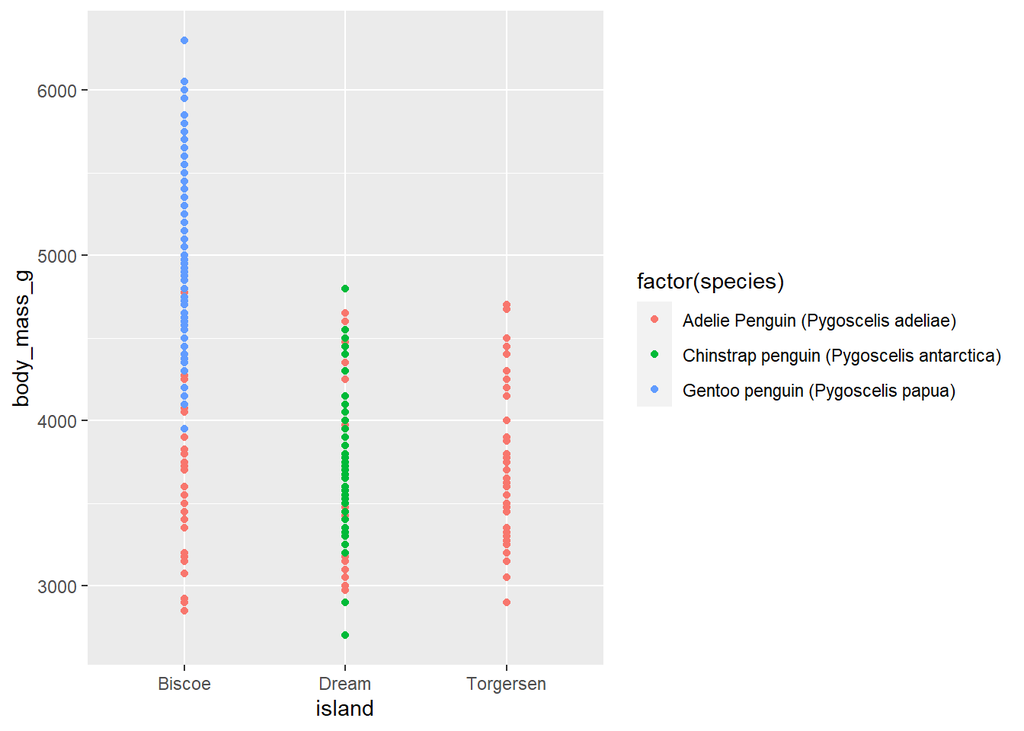

```r
island <- penguins_raw$Island
body_mass_g <- penguins_raw$`Body Mass (g)`
species <- penguins_raw$Species
#species

#plotting with all species
ggplot(data= penguins_raw, aes(x = island, y = body_mass_g), na.rm= TRUE)+
  geom_point(aes(colour = factor(species)))
```

```r
#then plotting with adelie filtered
adelie <- filter(penguins_raw,species == "Adelie Penguin (Pygoscelis adeliae)" )
#adelie

#dropping NAs
adelie<-adelie[-which(is.na(adelie$`Body Mass (g)`)),]

#checking they are gone
adelie$`Body Mass (g)`
```

```
##   [1] 3750 3800 3250 3450 3650 3625 4675 3475 4250 3300 3700 3200 3800 4400 3700
##  [16] 3450 4500 3325 4200 3400 3600 3800 3950 3800 3800 3550 3200 3150 3950 3250
##  [31] 3900 3300 3900 3325 4150 3950 3550 3300 4650 3150 3900 3100 4400 3000 4600
##  [46] 3425 2975 3450 4150 3500 4300 3450 4050 2900 3700 3550 3800 2850 3750 3150
##  [61] 4400 3600 4050 2850 3950 3350 4100 3050 4450 3600 3900 3550 4150 3700 4250
##  [76] 3700 3900 3550 4000 3200 4700 3800 4200 3350 3550 3800 3500 3950 3600 3550
##  [91] 4300 3400 4450 3300 4300 3700 4350 2900 4100 3725 4725 3075 4250 2925 3550
## [106] 3750 3900 3175 4775 3825 4600 3200 4275 3900 4075 2900 3775 3350 3325 3150
## [121] 3500 3450 3875 3050 4000 3275 4300 3050 4000 3325 3500 3500 4475 3425 3900
## [136] 3175 3975 3400 4250 3400 3475 3050 3725 3000 3650 4250 3475 3450 3750 3700
## [151] 4000
```

```r
adelie$Island
```

```
##   [1] "Torgersen" "Torgersen" "Torgersen" "Torgersen" "Torgersen" "Torgersen"
##   [7] "Torgersen" "Torgersen" "Torgersen" "Torgersen" "Torgersen" "Torgersen"
##  [13] "Torgersen" "Torgersen" "Torgersen" "Torgersen" "Torgersen" "Torgersen"
##  [19] "Torgersen" "Biscoe"    "Biscoe"    "Biscoe"    "Biscoe"    "Biscoe"
##  [25] "Biscoe"    "Biscoe"    "Biscoe"    "Biscoe"    "Biscoe"    "Dream"
##  [31] "Dream"     "Dream"     "Dream"     "Dream"     "Dream"     "Dream"
##  [37] "Dream"     "Dream"     "Dream"     "Dream"     "Dream"     "Dream"
##  [43] "Dream"     "Dream"     "Dream"     "Dream"     "Dream"     "Dream"
##  [49] "Dream"     "Biscoe"    "Biscoe"    "Biscoe"    "Biscoe"    "Biscoe"
##  [55] "Biscoe"    "Biscoe"    "Biscoe"    "Biscoe"    "Biscoe"    "Biscoe"
##  [61] "Biscoe"    "Biscoe"    "Biscoe"    "Biscoe"    "Biscoe"    "Biscoe"
##  [67] "Biscoe"    "Torgersen" "Torgersen" "Torgersen" "Torgersen" "Torgersen"
##  [73] "Torgersen" "Torgersen" "Torgersen" "Torgersen" "Torgersen" "Torgersen"
##  [79] "Torgersen" "Torgersen" "Torgersen" "Torgersen" "Torgersen" "Dream"
##  [85] "Dream"     "Dream"     "Dream"     "Dream"     "Dream"     "Dream"
##  [91] "Dream"     "Dream"     "Dream"     "Dream"     "Dream"     "Dream"
##  [97] "Dream"     "Dream"     "Dream"     "Biscoe"    "Biscoe"    "Biscoe"
## [103] "Biscoe"    "Biscoe"    "Biscoe"    "Biscoe"    "Biscoe"    "Biscoe"
## [109] "Biscoe"    "Biscoe"    "Biscoe"    "Biscoe"    "Biscoe"    "Biscoe"
## [115] "Biscoe"    "Torgersen" "Torgersen" "Torgersen" "Torgersen" "Torgersen"
## [121] "Torgersen" "Torgersen" "Torgersen" "Torgersen" "Torgersen" "Torgersen"
## [127] "Torgersen" "Torgersen" "Torgersen" "Torgersen" "Torgersen" "Dream"
## [133] "Dream"     "Dream"     "Dream"     "Dream"     "Dream"     "Dream"
## [139] "Dream"     "Dream"     "Dream"     "Dream"     "Dream"     "Dream"
## [145] "Dream"     "Dream"     "Dream"     "Dream"     "Dream"     "Dream"
## [151] "Dream"
```

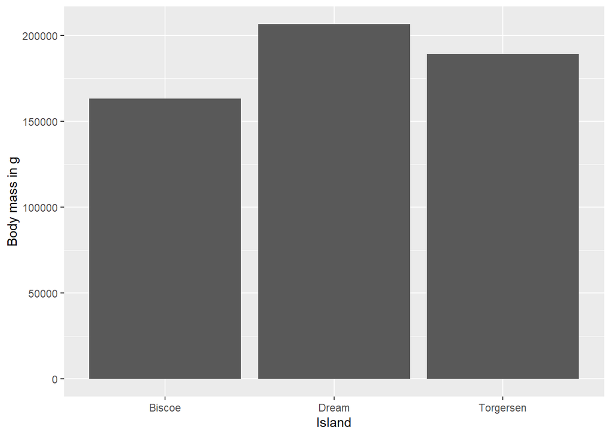

```r
ad_island <- adelie$Island
ad_body_mass_g <- adelie$`Body Mass (g)`


#first visualisations of the data

#ggplot(data= adelie, aes(x = ad_island, y = ad_body_mass_g))+
  #geom_point()

ggplot(adelie, aes(as.factor(ad_island), ad_body_mass_g)) +
    geom_bar(stat = "identity") +
    labs(y = "Body mass in g", x = "Island")
```

Here I looked around the data and decided to use the data for body mass and islands, for the adelie species I plotted a scatter graph, bar chart, then decided to keep the bar chart as it was a clearer representation of the results and better for the fact island is categorical data

### Hypothesis

There is a significant difference in the body mass of adelie penguins between the three islands -at least one island has a different mean

Null hypothesis= there is no significant difference in body mass of adelie penguins between the three islands -all the means are equal

### Statistical Methods

```r
#likely doing an ANOVA as there are 3 body mass means for the 3 different islands

#the anova test
adelie_aov <- aov(body_mass_g ~ island,
  data = adelie
)

summary(adelie_aov)
```

```
##              Df    Sum Sq  Mean Sq F value Pr(>F)
## island        2  86314512 43157256     110 <2e-16 ***
## Residuals   339 132993186   392310
## ---
## Signif. codes:  0 '***' 0.001 '**' 0.01 '*' 0.05 '.' 0.1 ' ' 1
## 2 observations deleted due to missingness
```

# Then checking the assumptions

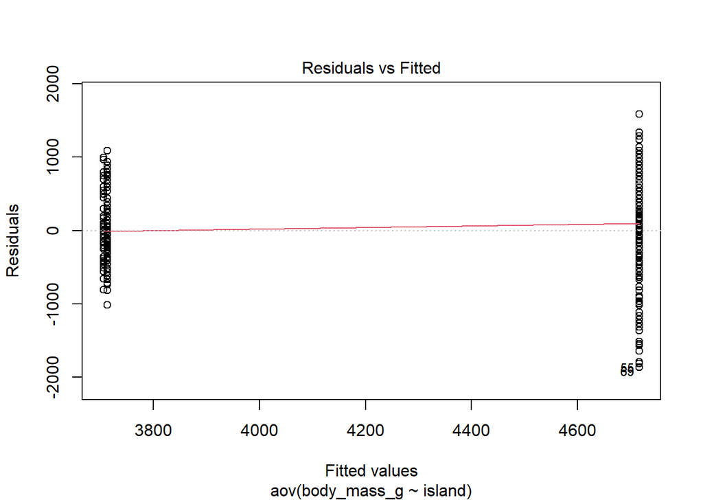

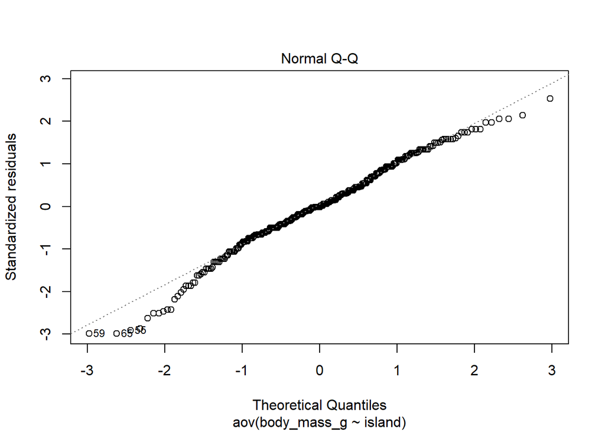

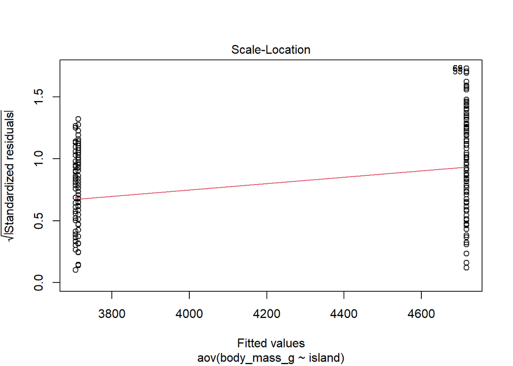

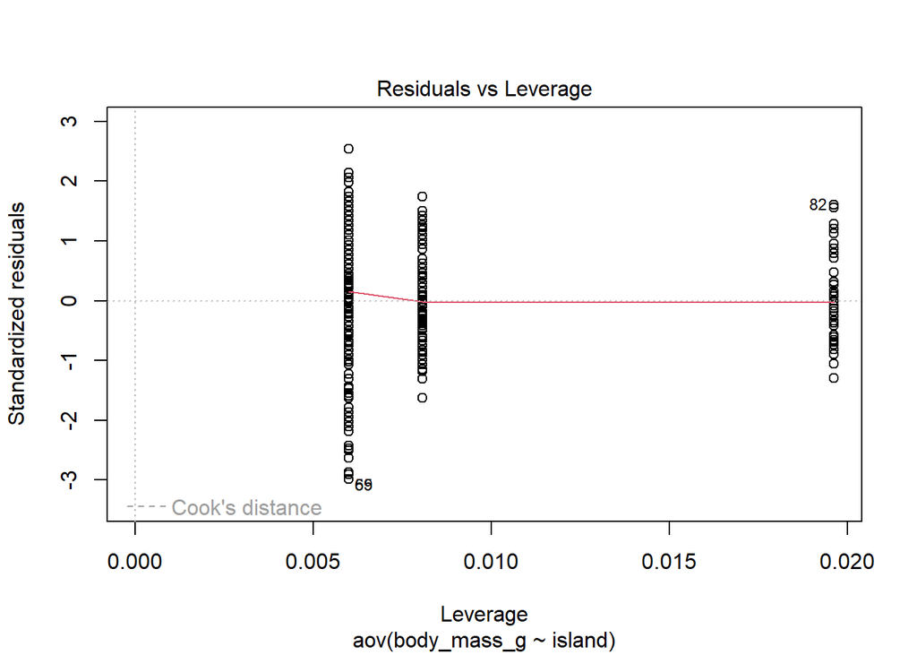

```r
plot(adelie_aov)
```

1. residual vs fitted is flat horizontally
2. normal qq plot looks pretty good, although ends are slightly curved
3. scale location plot is not horizontal, data is not equally spread across the graph which is quite concerning
4. residual vs leverage plot does not have any clear cookes lines

### Results & Discussion

```r
install.packages("remotes", repos = "http://cran.us.r-project.org")
remotes::install_github("easystats/report")
library("report")

report(adelie_aov)
```

```
## The ANOVA (formula: body_mass_g ~ island) suggests that:
##
##   - The main effect of island is statistically significant and large (F(2, 339) =
## 110.01, p < .001; Eta2 = 0.39, 95% CI [0.33, 1.00])
##
## Effect sizes were labelled following Field's (2013) recommendations.
```

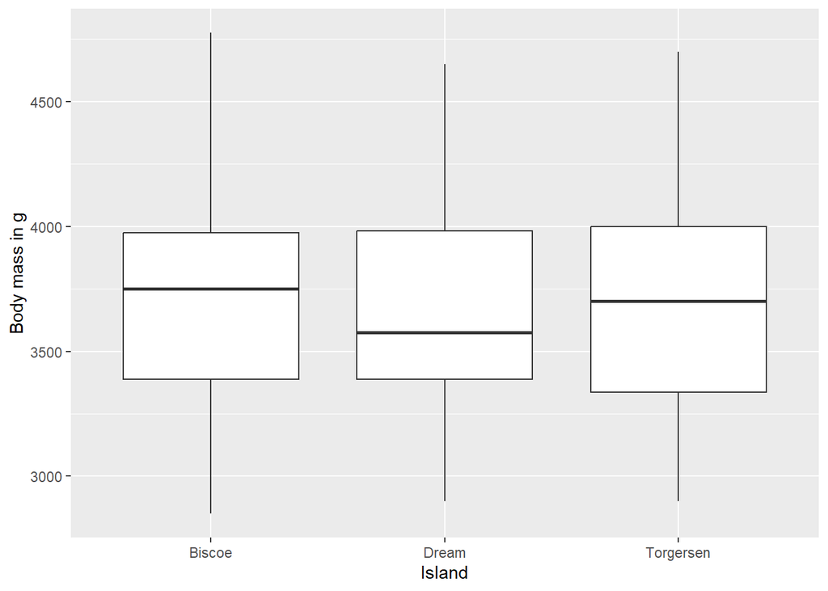

```r
ggplot(data= adelie, aes(x= factor(ad_island) , y = ad_body_mass_g), na.rm= TRUE)+
  geom_boxplot()+
 labs( x= ("Island"), y= ("Body mass in g"))
```

## QUESTION 3: Open Science

### a) GitHub

*Upload your RProject you created for **Question 2** and any files and subfolders used to GitHub. Do not include any identifiers such as your name. Make sure your GitHub repo is public.*

*GitHub link: https://github.com/clownFSH/Reproducibleassignment*

### b) Share your repo with a partner, download, and try to run their data pipeline.

*Partner’s GitHub link:https://github.com/skittles0811/ReproducibilityGithub*

### c) Reflect on your experience running their code. (300-500 words)

- *What elements of your partner’s code helped you to understand their data pipeline?* Their code is clear and easy to follow with comments added throughout. Each line is explained well and formatting is well done
- *Did it run? Did you need to fix anything?* The R markdown file had some problems with running as there was a problem with finding the csv that was saved in my partners one drive I am able to work around this by downloading the data myself from their github repository, and changing the line saying where the file is saved. It is the line of code that reads “penguins_raw <- read.csv(”C:\user…\penguins_raw_data.csv”)” that is stopping the rest of the document from working
- *What suggestions would you make for improving their code to make it more understandable or reproducible, and why?* Adding code to install the required packages will make the code more reproducible as loading the packages straight away will only work if the person receiving the code already has the relevant packages
- *If you needed to alter your partner’s figure using their code, do you think that would be easy or difficult, and why?* I would be able to edit my partner’s figure by using the functions they have saved in their github repository. This means I will not be overriding any of their data, I will instead be able to use their change their plot function to change the figures.

### d) Reflect on your own code based on your experience with your partner’s code and their review of yours. (300-500 words)

- *What improvements did they suggest, and do you agree?* My partner suggests adding more comments next to important lines of code, which I agree will make it more understandable. It may be a case of moving comments above chunks of code in line and between the lines of my code, to pinpoint which line in that chunk I am referring to.

My partner also suggested creating functions which I agree with, it will greatly improve the reproducibility of my code as I can then reuse that code more easily, at a later date

The suggestion to save a clean data file is also correct, so other people can start with the already cleaned data, currently they will have to go back to the raw data and clean the data themselves, which is an unecessary waste of time as I have already done it before, but not made it easily reproducible

- *What did you learn about writing code for other people?* I have learnt that writing code for others changes the way it look in comparison to if I was writing code for myself, as I want others to be able to use the same functions as I did. I going to work on improving this for my future code. I have learnt I am better at producing understandable than reproducible code, but that may be a big problem considering the amount of scientific data is not reproducible, slowing down the process of advancing research and using people’s time as they code the same things others have already done previously.